# Day 14: Which Model, When?

From one comparison to a full toolkit

Shahryar Minhas

## The Question That Outlasts the Course

What is the substantive quantity you want, where does the important dependence live, and which assumptions are you willing to defend?

Choose a model from the question and data structure. Do not choose a question because a familiar model is available.

Open the Day 14 path

## Days 8 Through 10 Built the Relational Toolkit

| Day | Main question | Tools you now have |
| --- | --- | --- |
| 8: Network foundations | What exactly are the actors, ties, eligible pairs, and patterns in this network? | `netify` for building, checking, reshaping, and describing network data |
| 9: SRM and blockmodels | Are broad actor differences or recurring relational roles organizing the ties? | `lame` and `blockmodels` for additive effects and cross-sectional roles; NetMix for actor-year role mixtures without a fitted transition model |
| 10: Latent distance, latent factors, and AME | Which pairs remain unusually compatible after measured covariates and broad actor differences? | `latentnet` for latent distance and `lame` for signed relational surfaces, covariate adjustment, uncertainty, and goodness-of-fit |

The sequence moved from defining ties, to finding broad actor structure, to modeling pair-specific structure that the measured variables missed.

Review the first half of the course map

## Days 11 Through 13 Added Structure, Change, and Design

| Day | Main question | Tools you now have |
| --- | --- | --- |
| 11: ERGM and TERGM | Do named configurations such as reciprocity or closure help describe one network or a panel of networks? | `ergm` and `btergm`, change statistics, simulation-based interpretation, and goodness-of-fit |
| 12: SAOM | What actor-oriented sequence of small tie and behavior changes could connect the observed waves? | `RSiena` with `netify`, method-of-moments estimation, micro-step interpretation, and simulation checks |
| 13: Network causal inference | What comparison would identify the effect, and how can interference break an ordinary design? | Exposure mappings, Horvitz-Thompson estimates, negative controls, and careful limits on causal claims |

These tools do not form a ladder from simple to advanced. They answer different questions about configurations, change between waves, and causal comparisons.

Review the second half of the course map

## Start by Naming the Target

Possible targets include:

- An observed covariate association with uncertainty that allows shared actors
- Actor sending and receiving propensities
- Discrete relational types
- A latent relational surface
- An explicit graph configuration such as closure
- Influence among actors

Is dependence something to account for, a process you want to describe, or the main thing you want to measure?

## Every Lens Must Earn Its Place

For each model, finish four sentences:

1. **The substantive question is…**
2. **This model helps because…**
3. **It is distinct from the previous lens because…**
4. **After fitting it, I can say…**

If the fourth sentence still sounds like package documentation, the model has not yet produced an applied result.

Read the model-by-model substantive interpretations

## The Same Network Becomes Different Evidence

| Lens | Pattern the model tries to explain |
| --- | --- |
| GLM | Measured dyadic associations |
| SRM | Persistent differences in actors’ overall activity |
| Blockmodel | A small set of recurring partner-list types |
| AME | Continuous pair-specific compatibility |
| ERGM | Named graph configurations such as shared partners |
| TERGM | Tie transitions across observed network waves |
| SAOM | Actor-oriented micro-changes between observed waves |

TERGM and SAOM require repeated network observations, so they belong in the course map but cannot be fitted to today’s single snapshot.

Compare the estimation strategies

## What Each Procedure Actually Fits

| Lens | Statistical target |
| --- | --- |
| GLM | Maximize dyad-level Bernoulli log-likelihood |
| Capstone SRM and AME | Sample a joint posterior distribution |
| Blockmodel | Maximize a variational likelihood lower bound |
| ERGM | Maximize a graph likelihood using simulated network statistics |
| TERGM with `btergm` | Fit a conditional tie-transition model by MPLE; use a temporal bootstrap for uncertainty |
| SAOM | Use simulated method of moments to match observed network and behavior change statistics |

These are the model-fitting procedures covered in the course. DCR appears after the GLM because it recalculates uncertainty rather than fitting a new network process.

The fast longitudinal `lame` examples used ALS point estimation instead of posterior sampling.

Connect Every Algorithm to Its Target

## One Dataset Keeps the Models Comparable

The rebel-cooperation network supplies:

- 30 armed organizations active in the Syrian civil war
- An undirected tie for at least one claimed tactical joint operation, July 2012 through June 2015
- Organization ideology and size
- Pair-level ideological distance, power difference, shared location, and shared sponsor
- Strong differences in how many cooperation partners organizations have

Every lens sees the same observed network, but each conditions on a different representation of its dependence.

Inspect the common data

## Lens 0: Start With the Dyadic GLM

What it asks

Which measured pair characteristics are associated with recorded cooperation?

What it initially assumes

The usual GLM uncertainty calculation treats the 435 organization pairs as independent rows.

The GLM gives us familiar conditional associations. Before reading its intervals, we need to account for the fact that many rows contain the same organizations.

Fit the dyadic GLM

## What Dyadic Cluster-Robust Standard Errors Do

The rows in a dyadic regression overlap:

- ANF with ASIM and ANF with another organization both contain ANF.
- Unmeasured changes involving ANF can therefore affect both regression errors.

Dyadic cluster-robust standard errors, or DCRSEs, allow errors to be correlated when two dyads share either organization.

DCR keeps the GLM coefficients exactly the same and recalculates only their standard errors, intervals, and tests. Here, the power-difference interval widens across zero, while several other intervals narrow.

See the shared-actor calculation

## What DCR Does Not Fix

- It does not repair an omitted actor trait, a wrong functional form, or a missing network process.
- It still treats dyads with no shared organization as independent. Broader shocks or network dependence can violate that assumption.
- Its justification is asymptotic in the number of actors. With only 30 organizations, the intervals can be unstable.
- It does not turn a conditional association into a causal effect.
- A corrected standard error can be larger or smaller because the estimated shared-actor covariances can have either sign.

DCR is an uncertainty correction for a declared regression, not a model of how the network formed.

Read the DCR caveats

## Lens 1: SRM Locates Organization-Level Dependence

$$\eta_{ij}=x_{ij}^{\mathsf T}\beta+a_i+a_j$$

Because this cooperation network is undirected, the SRM asks:

- Which organizations cooperate with more partners than the measured covariates predict?
- How much of the network’s hub structure is organization-level heterogeneity?
- Which covariate results change after every organization receives an additive effect?

ANF and ASIM have the largest fitted overall cooperation effects. The SRM reproduces the observed spread in organizations’ numbers of partners without adding a separate friend-of-a-friend term.

Fit the SRM lens

## Lens 2: Blockmodels Ask Whether Actors Come in Kinds

$$\Pr(Y_{ij}=1\mid z_i,z_j)=\theta_{z_i z_j}$$

Can a small number of relational roles summarize which organizations cooperate?

| Role Pair | Fitted Cooperation Probability |
| --- | --- |
| Core with core | 0.96 |
| Core with periphery | 0.74 |
| Periphery with periphery | 0.11 |

The fitted roles place ANF and ASIM in a two-organization core. The hard partition leaves only one core-to-core pair. Variational EM also uses soft memberships from all dyads, but a role represented by only two organizations remains fragile. Read this as a hub-versus-periphery summary, not as two coalition communities.

Fit the blockmodel lens

## Lens 3: AME Adds a Relational Surface

$$\eta_{ij}=x_{ij}^{\mathsf T}\beta+a_i+a_j+u_i^{\mathsf T}\Lambda u_j$$

The SRM gives each organization one overall cooperation effect. AME adds a pair-specific score:

- A high score raises fitted cooperation for that particular pair.
- A low score lowers fitted cooperation for that particular pair.
- The scores summarize recurring partner patterns that the measured variables and overall organization effects missed.

Shared location remains clearly positive. The ideology-distance result becomes uncertain after the pair-specific surface is included, so the measured ideology difference and the latent partner pattern compete to explain some of the same ties.

Fit the AME lens

## Lens 4: ERGM Makes Configurations Explicit

$$\Pr(Y=y)\propto\exp\{\theta^{\mathsf T}g(y)\}$$

Holding the rest of the network fixed, does a proposed tie receive greater conditional odds when it adds shared partners?

Use change statistics and simulation to interpret:

- Edges and covariates
- Actor sociality and degree-related terms
- Geometrically weighted closure

Fit the ERGM lens

## Why Hubs Can Be Mistaken for Closure

ANF and ASIM cooperate with many organizations. That alone creates many pairs that share a cooperation partner, even if organizations did not choose partners through a friend-of-a-friend process.

| Specification | What the simulations show |
| --- | --- |
| Covariates plus shared partners | Simulations have too little variation in partner counts and too much transitivity |
| Add one curved degree term | Improves AIC, but the observed values remain outside both simulation intervals |
| Give each organization its own baseline activity | The two observed values fall inside their simulation intervals; the remaining shared-partner coefficient interval includes zero |

Within the final, highly flexible specification, the remaining shared-partner association is imprecise and the two selected simulation checks do not reveal a mismatch. Do not compare the shared-partner coefficients across specifications as though they estimated the same effect.

With 29 sociality parameters and only 85 ties, matching degree heterogeneity is partly built into the final model. The nodal covariates also leave when sociality enters, so this is not a one-term-at-a-time comparison.

## Inside the Simulation Interval Is Good News, with Limits

| Final sociality ERGM | Observed | Simulated median | 95% simulation interval |
| --- | --- | --- | --- |
| Variation in organizations’ partner rates | 0.184 | 0.190 | [0.172, 0.207] |
| Centered transitivity dependence | 0.007 | -0.018 | [-0.075, 0.061] |

Both observed values are inside their intervals. For these two checks, the simulations do not reveal a mismatch. The median shows where a typical simulated network lands.

This does not establish overall fit. We checked only two summaries with 200 simulations. Each row has its own interval; this is not one simultaneous band across every diagnostic. The negative transitivity values are possible because this is a centered dependence score, not a triangle count.

## What Did Each Model Help Us Learn?

| Lens | What it added | Main result in this network |
| --- | --- | --- |
| GLM + DCR | Measured pair traits with shared-actor uncertainty | Location, ideology, and combined group size remain associated with cooperation |
| SRM | One overall cooperation tendency per organization | ANF and ASIM account for much of the hub structure |
| Blockmodel | Discrete partner-list types | A small two-organization core and a heterogeneous periphery |
| AME | Continuous pair-specific structure | Shared location remains; the ideology interval includes zero |
| ERGM | Explicit shared-partner structure | After organization-specific activity enters, the shared-partner interval includes zero and simulations reproduce both focal patterns |

The models reveal different parts of the same network because they ask different questions.

Read the model comparison

## After Naming the Target, Preserve the Data Structure

One snapshot

**Cross-sectional**

GLM/DCR, SRM, blocks, AME, ERGM

Panel waves

**Longitudinal**

TERGM, SAOM, dynamic latent models

Treatment spills over

**Causal design**

Day 13’s exposure and comparison logic

Use the decision framework

## Choose a Model in Three Steps

Start with what you want to learn, not with the package you want to use.

1. **Say the question in ordinary language.** Example: Which organizations cooperate unusually widely?
2. **Choose the model feature that answers it.** An SRM gives each organization its own overall cooperation tendency.
3. **Name the check that could change your mind.** If the SRM still misses important partner patterns, add a blockmodel, AME surface, or explicit ERGM configuration depending on the miss.

The next model should address a specific problem that the first model left behind.

## Four Studies, Four Lessons We Can Reuse

| Study | What happened | Lesson for our research |
| --- | --- | --- |
| Voting message | A message sent to one voter also raised turnout for the other voter in the household | An intervention can reach people who were not directly treated |
| School anti-conflict program | Selected students were invited to lead an anti-conflict program, and their friends could be exposed without receiving an invitation | A student’s own assignment, exposure through assigned peers, and the wider program-school context are different |
| Ghana election observers | Observers monitored voter-registration centers to deter manipulation. Registration growth fell at monitored centers and rose at nearby unmonitored centers | An intervention may move behavior somewhere else |
| Friends’ GPA | A large peer association became much smaller after double-negative-control adjustment under additional assumptions | Similar friends do not by themselves show peer influence |

For our own studies, ask where an effect can travel, where behavior can move, and why connected units already resemble one another.

## Carry Six Questions From the Causal Lecture

1. **What changes?** Name the treatment or exposure precisely.
2. **Whose outcome may change, and when?**
3. **Compared with what?** Name the units or periods supplying the comparison.
4. **Why might treated and untreated cases already differ?**
5. **Can treatment reach a unit through its network neighbors?**
6. **Which result would still be useful if a causal claim is not credible?**

Do this before choosing a network model. A sophisticated dependence model cannot repair a comparison that never identified the effect.

Apply the observational research checklist

## Turn the Questions Into a Workable Analysis

**Example: Do sanctions reduce later trade?**

- Define the treatment as a sanction imposed before the trade outcome.
- Compare sanctioned and unsanctioned pair-periods with similar pre-treatment histories.
- Measure pre-sanction trade, security relations, regime ties, and economic conditions.
- If allies’ sanctions may alter the focal pair’s trade, define that indirect exposure.
- Use pre-treatment outcomes or negative controls to probe hidden selection.
- Model repeated states and dyads, but keep that dependence problem separate from causal identification.

If the conditions producing sanctions may also reduce trade, report an association and name that remaining threat.

See IR and comparative examples

## A Negative Control Starts as a Deliberate Non-Effect

Egami and Tchetgen Tchetgen (2024) ask whether students do better academically when their friends have higher GPAs.

**Main exposure:** friends’ average baseline GPA  
**Outcome:** the student’s later GPA  
**Confounding worry:** friends may share motivation, family resources, courses, stress, or school conditions before any influence occurs

Friends’ baseline headaches may reflect that hidden background, but should not directly change the student’s later GPA. As a basic placebo check, an association between friends’ headaches and later GPA would warn that hidden selection may remain.

## Their Method Uses Two Controls to Adjust, Not Just Diagnose

| Role | Variable |
| --- | --- |
| Negative-control exposure | Friends’ headaches, or peers-of-peers’ GPA in the alternative analysis |
| Negative-control outcome | Student’s own baseline GPA |

Egami and Tchetgen Tchetgen use the pair to estimate a **confounding bridge** with GMM. Under additional exclusion, relevance, completeness, and bridge assumptions, that bridge adjusts the peer-GPA estimate.

The correction is not “put headaches into the regression.” Two negative controls supply proxy information about hidden confounding, and a specialized estimator uses that information.

## The Frontier: Predicting Cooperation From Network Position

**Question:** Can walk-based coordinates recover hidden cooperation ties better than simple network summaries?

Across 30 repeated splits, we hide 17 cooperation ties and 17 non-ties before constructing any features.

| Predictors | Mean held-out AUC |
| --- | --- |
| Degree and shared-neighbor summaries | **0.82** |
| Node2vec-style walk coordinates | 0.60 |
| Both together | 0.80 |

AUC is 0.50 for chance ranking and 1.00 for perfect ranking. In this small, hub-dominated network, the embedding does not beat the simple baseline.

The teaching code uses node2vec’s biased walks, then compresses the resulting neighborhood table with PPMI and SVD. It demonstrates the walk-embedding idea but is not the original skip-gram implementation.

See the cooperation example

## What Node2vec Does With the Network

1. Reserve ties and non-ties for testing, then remove the test ties from the graph.
2. Start at one organization and follow a few observed ties.
3. Repeat these short network trips from every organization.
4. Give every organization a short row of coordinates. Organizations reached in similar network neighborhoods receive similar rows.
5. Combine two organizations’ profiles, fit a model on visible pairs, and test it on hidden pairs.

The trips are created by the computer. They are not organizations moving through the conflict.

The numbers are coordinates in an embedding space, much like factor scores. We use their relative positions for prediction, but an individual axis does not automatically mean ideology, power, or influence.

## Three Methods, Three Definitions of “Similar”

| Method | The question used to place actors near one another |
| --- | --- |
| DeepWalk (Perozzi et al. 2014) | Do ordinary short walks repeatedly encounter these actors in similar contexts? |
| LINE (Tang et al. 2015) | Are the actors directly connected, or do they have similar immediate neighbor lists? |
| Node2vec (Grover and Leskovec 2016) | Should similarity emphasize the same local neighborhood or a similar role elsewhere in the graph? |

All three return a short coordinate row for each actor. They differ in which network evidence makes two rows similar.

See how the methods connect

## NetMF and GraphSAGE Solve Two Practical Problems

NetMF: What Is Being Compressed?

First build a table. Row $i$, column $j$ records how often walks from actor $i$ reach actor $j$, relative to chance.

Actors with similar rows have similar sampled neighborhoods. SVD compresses each long row into a few coordinates.

GraphSAGE: What About a New Actor?

Node2vec stores coordinates for the actors used in training. A new actor has no stored row.

GraphSAGE learns a recipe using an actor’s traits and neighbors. Apply that recipe to construct coordinates for a new actor.

NetMF makes the neighborhood table visible. GraphSAGE learns a reusable coordinate-making recipe.

See the matrix and new-actor connections

## Question 1: Can We Predict a Hidden Tie?

**Syrian cooperation example**

1. Before learning coordinates, reserve some cooperation ties and an appropriate sample of non-ties.
2. Remove the reserved ties, then learn the walk-based coordinates from the reduced graph.
3. Turn each candidate pair into predictors using the two organizations’ coordinates.
4. Fit on the remaining pairs and predict only the pairs hidden in step 1.
5. Compare with degree and shared-partner baselines. In a full application, also add observed pair characteristics.

A useful result would be: network coordinates improve prediction of held-back cooperation ties beyond the baselines. It would not tell us why those ties formed.

## Question 2: Can Network Position Predict an Actor Label?

Brown et al. (2021) use linking patterns to help predict ideological labels for Twitter users and internet domains.

- The outcome belongs to an **actor**, not a pair.
- The predictors summarize which other actors or domains link to it.
- Keep test actors in the graph, but hide their labels from the classifier.
- Compare network features with a simple label-frequency baseline and with useful non-network attributes.
- Check whether performance survives across different samples, platforms, or time periods.

The warranted claim is predictive: actors’ link neighborhoods contain information about the held-out labels. The coordinates do not become an ideology scale automatically.

## Question 3: Can We Build Features for a New Actor?

Ordinary node2vec learns a separate coordinate row for every actor in the training graph. A genuinely new actor has no stored row.

GraphSAGE instead learns a rule:

1. Start with the new actor’s observed attributes.
2. summarize the attributes of its observed neighbors;
3. combine those summaries using the learned rule;
4. produce coordinates for the new actor;
5. use those coordinates in the prediction task.

Test on actors or later periods excluded from training. The method still needs observed attributes and enough neighborhood information for the new actor.

See how the three prediction tasks differ

## Node2vec and Day 10 Are Cousins

|  | Node2vec and related graph ML | Latent factor model or AME |
| --- | --- | --- |
| Main goal | Build useful features for prediction | Explain a declared dyadic outcome |
| What gets compressed | Network neighborhoods | Unexplained patterns in the outcome |
| What we check | Performance on genuinely hidden cases | Uncertainty, prediction, and network fit |

Both approaches reduce complicated relational patterns to a few numbers per actor. They do that for different reasons.

If node2vec improves hidden-tie prediction, say exactly that. Do not rename an axis “ideology,” “influence,” or “alliance” without outside evidence.

Compare node2vec with latent factor models

## SIR Asks How Conflict Patterns Carry Forward

Minhas and Hoff (2026) study monthly **material-conflict events among countries**. These include physical attacks, destruction of property, and other coercive actions recorded by ICEWS.

The model separates two questions:

- **Direct dyadic history:** Does state $i$ direct more conflict toward state $j$ after earlier conflict within that same pair?
- **Network influence:** Does conflict elsewhere in the system help predict which states $i$ targets next and which states $j$ is targeted by next?

Here, influence means a lagged predictive association. It does not by itself show imitation, coordination, or a causal effect.

Open the influence application

## Direct Effects and Influence Paths Are Different

**Direct part of the model**

- The pair’s earlier conflict and conflict in the reverse direction
- Geographic distance, joint democracy, alliance, trade, and verbal cooperation

**Influence part of the model**

- **Sender side:** Does state $i$ target countries that its allies or verbal-cooperation partners targeted previously?
- **Receiver side:** Are geographically nearby states targeted by similar sets of countries?

The direct terms describe one state pair’s history. The influence terms ask whether other relationships help predict that pair’s next outcome.

## What the Published SIR Application Finds

**Alliances organize sender-side influence**

States tend to direct more material-conflict events toward countries that their allies fought in the previous month.

**Verbal cooperation also organizes sender-side influence**

States tend to target some of the same countries as their cooperative diplomatic partners.

**Geography organizes receiver-side influence**

Nearby states tend to receive conflict from similar sets of senders.

These are conditional temporal patterns. The model does not establish that allies coordinated, that one state copied another, or that proximity caused conflict.

## The Same Modeling Move Can Structure Different Objects

| Model | Hidden object | What observed covariates do |
| --- | --- | --- |
| NetMix | An actor-year’s mixture of discrete relational roles | Nodal covariates can predict which role mixture an actor-year tends to occupy |
| Austin et al. (2013) | A continuous latent social position | Nodal covariates define the expected position; a random residual lets actors depart from it |
| SIR | A directed channel of influence over time | Observed relational matrices define possible channels; estimated weights show which channels carry the lagged association |

The shared idea is to make a hidden relational object partly explainable by observed variables. The hidden object is different in each model.

Compare the three covariate-defined structures

## How SIR Is Estimated

For monthly conflict counts,

$$\eta_{ijt}=z_{ijt}^{\mathsf T}\theta+\left(A X_{t-1}B^{\mathsf T}\right)_{ij},
\qquad
A=\sum_r\alpha_rW_r,\qquad B=\sum_r\beta_rW_r.$$

- $z_{ijt}^{\mathsf T}\theta$ contains the direct dyadic predictors.
- $X_{t-1}$ is the previous month’s conflict network.
- $A$ describes sender-side channels; $B$ describes receiver-side channels.

The Poisson estimator alternates two familiar jobs:

1. Hold the receiver side fixed and update the direct and sender-side coefficients.
2. Hold the sender side fixed and update the receiver-side coefficients.
3. Repeat until the fitted likelihood and coefficients stabilize.

Instead of estimating one unrestricted influence parameter for every country pair, SIR learns which observed relationships carry the lagged association.

See how SIR is estimated and checked

## Multilayer Networks Keep Several Relations Visible

For the same source $i$ and target $j$,

$$Y_{ij\ell}$$

keeps relation type $\ell$ visible. With repeated years, the object becomes $Y_{ij\ell t}$.

Examples include:

- Military threats, sanctions, trade, and alliances among the same states
- Verbal cooperation, material cooperation, verbal conflict, and material conflict
- Advice, friendship, and collaboration among the same people

A multilayer question asks whether the same actors and dyads play similar or different roles across relations.

Keep the layer index visible

## Theory Can Make the Layers Interdependent

With repeated observations, $Y_{ij\ell t}$ can represent several relations evolving together.

- **International relations:** Conflict can reduce trade, while trade dependence may discourage later conflict.
- **American politics:** Legislative cosponsorship can build voting coalitions, while repeated voting agreement can make future cosponsorship easier.
- **Education:** Friendship can create opportunities for study help, while repeated help can strengthen a friendship.

A multilayer design is useful when two relations may shape one another. Repeated observations help establish sequence, but they do not by themselves establish causation.

Develop a multilayer research question

## What `netify` Can Do With the Layers

| Task | Function |
| --- | --- |
| Combine aligned network objects and keep the layer labels | `layer_netify()` |
| Verify and summarize the object | `is_multilayer()`, `n_layers()`, `summary()` |
| Extract one relation or its matrix | `subset(..., layers = )`, `as.matrix(..., layer = )` |
| Compare ties or attributes across layers | `compare_networks()` |
| Draw all layers with a common data structure | `plot()` |

`netify` handles construction, validation, extraction, comparison, and visualization. The substantive question still determines whether layers should be modeled jointly.

Use the multilayer helpers

## One Network Can Contain Four Different Stories

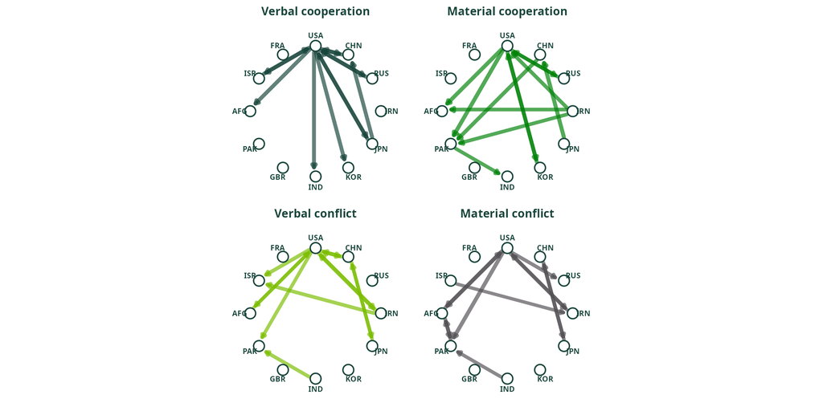

ICEWS, 2010. The same 12 states appear in fixed positions, and each panel shows its 12 highest-volume directed pairs. Keeping the layers separate reveals changing partner patterns that an aggregated “any interaction” network would hide.

## Do Not Flatten Away the Question

Collapsing verbal cooperation, material cooperation, verbal conflict, and material conflict into “any interaction” changes the outcome.

Fitting four separate networks preserves the outcomes but cannot estimate:

- A source profile shared across relations
- A target profile shared across relations
- Which layers express the same relational component
- Shared cross-layer mean structure

Keep the layer index when the question concerns whether the same dyadic pattern appears in several kinds of interaction.

See the four ICEWS layers

## Follow One Shared Component Across the Layers

For component $r$, the contribution to one source-target-layer cell is

$$u_{ir}\times v_{jr}\times w_{\ell r}.$$

1. $u_{ir}$ says how strongly source $i$ expresses the source side of this profile.
2. $v_{jr}$ says how strongly target $j$ expresses the target side.
3. Their product identifies source-target pairs matching the profile.
4. $w_{\ell r}$ says whether that same pair pattern is strong, weak, reversed, or absent in layer $\ell$.

One component can describe the same recurring set of dyads across all four relations while allowing conflict to express it more strongly than cooperation.

## A Joint Multilinear Model Shares Actor Profiles

$$\eta_{ij\ell}
=x_{ij\ell}^{\mathsf T}\beta_\ell
+a_{i\ell}+b_{j\ell}
+\sum_{r=1}^{R}u_{ir}v_{jr}w_{\ell r}.$$

- $\beta_\ell$: relation-specific measured associations
- $a_{i\ell},b_{j\ell}$: layer-specific source activity and target exposure
- $u_{ir},v_{jr}$: source and target profiles shared across layers
- $w_{\ell r}$: how strongly layer $\ell$ expresses component $r$

The full model can include $x_{ij\ell}^{\mathsf T}\beta_\ell$. The teaching fit below omits that block and models separately standardized $\log(1+\text{count})$ layers.

Separate fits can find a different factor surface in each layer, but they do not estimate one shared $U,V$ profile or the layer weights $W$ that reveal where it recurs.

Read the joint model

## What the Tensor Estimator Optimizes

This teaching fit uses the same broad ALS logic as `lame`. For the transformed Gaussian outcome, it minimizes

$$\min \sum_{i\ne j,\ell}
\left(Y^*_{ij\ell}-\eta_{ij\ell}\right)^2.$$

1. Remove the current layer-specific source and target effects.
2. Hold $V,W$ fixed and solve an ordinary least-squares update for $U$.
3. Cycle through analogous updates for $V$ and $W$, then refresh the additive effects.
4. Repeat to convergence. This example compares eight starts; research should use more starts and compare ranks out of sample.

Unlike ERGM pseudolikelihood, these are conditional updates of one joint squared-error objective. The objective is nonconvex, so different starts can reach different solutions. This fast fit does not provide posterior uncertainty.

Open the reproducible rank-2 fit

## Overlap Needs a Density Benchmark

| Layer Pair | Threshold | Jaccard | Overlap Lift |
| --- | --- | --- | --- |
| Verbal conflict with material conflict | At least 1 event | 0.385 | 4.91 |
| Verbal conflict with material conflict | At least 5 events | 0.402 | 16.39 |

At the one-event threshold:

- **Jaccard 0.385:** 38.5% of dyads appearing in either conflict layer appear in both.
- **Lift 4.91:** a dyad appears in both layers 4.91 times as often as independent layers with these densities would predict.

At five events, the overlap remains about 40%, while lift rises because high-volume dyads are rare. The result is robust to this threshold change, but it does not tell us which layer came first.

## What Should We Do After Finding Layer Overlap?

1. **Check measurement choices.** Repeat the comparison across meaningful event thresholds and coding rules.
2. **Use a stronger null.** Ask whether overlap remains after preserving actor activity, time patterns, or other obvious sources of co-occurrence.
3. **Match the model to the claim.** Use a joint factor model for shared profiles; use repeated layers and lags for cross-layer prediction.
4. **Check what remains unexplained.** Compare held-out prediction and residual degree, triad, and cross-layer overlap patterns.

Overlap is evidence that the layers are related. Theory and time ordering determine whether the next step is a joint description, a dynamic model, or a causal design.

## Do the Same State Pairs Stand Out Across Relations?

First remove each state’s broad source and target activity within every layer. Then ask whether a few recurring **pair patterns** explain what remains.

**Pattern 1**

After removing the United States’ overall source and target activity, particular United States dyads remain unusually active across several relations.

**Pattern 2**

Pairs involving Iran, Israel, Lebanon, Egypt, and Iraq repeatedly stand out.

Both patterns appear in verbal cooperation, material cooperation, verbal conflict, and material conflict. Together they account for about 23% of the transformed variation left after the broad actor effects.

The useful finding is not “two components.” It is that some state pairs remain unusually active across several different relations. The United States-centered pattern refers to unusually active pairs, not simply to high United States activity overall.

## How Should We Check the Joint Fit?

- Compare rank 1, rank 2, and higher ranks on held-out actor-pair-layer cells.
- Repeat ALS from several starts and retain solutions reaching the best objective.
- Add defensible covariates and see whether the shared profiles remain.
- Check residual source activity, target exposure, triads, and cross-layer overlap.
- Use a binary or count likelihood when that matches the outcome, and use bootstrap or Bayesian fitting when uncertainty is required.

The current fit shows a useful shared pattern. These checks determine whether it is stable enough to support a research claim.

## Scaling Shortcuts Change the Statistical Job

| Procedure | Faster route used in this course | What the shortcut does not supply |
| --- | --- | --- |
| `lame` and tensor point fits | ALS block-coordinate updates | A posterior distribution; protection from local optima |
| Capstone ERGM | MCMC maximum likelihood | Cheap computation or guaranteed simulation mixing |
| TERGM with `btergm` | MPLE plus a temporal bootstrap | Exact graph-likelihood estimation |
| Blockmodels | Variational EM | Exact posterior exploration |
| Bayesian AME | MCMC posterior sampling | Cheap computation or guaranteed chain mixing |
| Graph embeddings | Sampled walks and negative examples | A likelihood for the original tie outcome |

Ask what the procedure optimizes, what information it samples or approximates, and whether the resulting uncertainty matches the claim.

Open the scale discussion

## Write the Model Choice as an Argument

Use this paragraph structure:

1. **Question:** Name the estimand.
2. **Data:** State the network, time, and eligibility structure.
3. **Primary model:** Explain where it represents dependence.
4. **Runner-up:** Name the strongest alternative representation.
5. **Flip condition:** Give a specific diagnostic that would change the choice.
6. **Claim:** State what the fitted result would and would not establish.

## Published Example: With Whom Do Syrian Rebels Cooperate?

Gade et al. (2019) ask why armed organizations chose some partners rather than others during the Syrian civil war.

**Data:** Claims of tactical joint operations from July 2012 through June 2015, combined with measures of ideology, power, state sponsorship, and shared location.

**Competing explanations:** Rebels may choose ideologically similar partners, partners of similar strength, or partners backed by the same state.

This is the published study behind today’s application. The paper models the square root of the number of claimed joint operations. The capstone models whether any claimed joint operation was recorded.

## Work Through Their Model-Choice Argument

| Framework part | Application |
| --- | --- |
| Question | Which group differences are associated with more joint operations? |
| Primary model | AME regression, representing broad organization activity and remaining higher-order dependence |
| Model runner-up | An ERGM with the same covariates, organization heterogeneity, and any theoretically named configurations; the paper does not fit it |
| Published robustness check | Activity-constrained simulations based on observed joint-operation counts |
| Flip condition | Reconsider ideology if it disappears with shared location or if the simulations reproduce it without ideology |
| Claim | Ideologically closer groups cooperated more often; that pattern does not identify why they chose one another |

Read the full published example

## What the Published Comparison Changed

- Ideological proximity had the clearest and most consistent association with cooperation across the AME specifications.
- Shared location also mattered, so geographic opportunity could not be ignored.
- Evidence for power similarity was weaker and less consistent.
- Shared state sponsorship did not receive clear support.
- Activity-constrained simulations also showed more ideological similarity than activity levels alone would generate.

The paper’s ideology result and the capstone’s AME interval need not match. The outcome and conditioning set are different, so they estimate different associations.

The useful argument combines a substantive question, a dependence model, a simpler check, and a bounded conclusion. It does not declare one method the universal winner.

## The Map, Filled In

Build and describe

`netify`, summaries, centrality, communities

Actors and latent structure

SRM, blocks, latent distance, latent factors, AME

Graph configurations

ERGM and TERGM

Actor-oriented change

SAOM

Identification and uncertainty

DCR, exposure mappings, Horvitz-Thompson estimators, negative controls

Frontier tools

Node2vec, tensors, SIR, multilayer models

No cell replaces the others. Each makes a different part of relational structure explicit.

Return to the completed map

## After the Models Run, Write the Substantive Paragraph

Include the question, model choice, substantive result, diagnostic, limit, and the finding that would change the model choice.

“ANF and ASIM cooperate with far more organizations than the rest. In the initial ERGM, ties between organizations with shared partners receive a clear positive conditional association. After every organization receives its own baseline propensity to cooperate, the shared-partner interval includes zero and the simulations cover the two selected scalar yardsticks. This saturated diagnostic does not clearly separate an additional shared-partner pattern from the hub structure. It is not evidence that closure never occurs.”

Read the full interpretation guide

## What to Take With You

1. Define actors, ties, eligibility, missingness, and time before modeling.
2. Identify where the important variation and dependence live.
3. Match the model to the estimand rather than to a preferred software package.
4. Diagnose the feature that would change the substantive conclusion.
5. Treat latent quantities, graph statistics, temporal mechanisms, and robust standard errors as different quantities that require different interpretations.

The best network model is not the one that explains everything. It is the one whose question, assumptions, diagnostics, and claim you can state clearly and defend.